# Commercial Fishing

Jo Hardin

6/8/2021

### Alt text!

Thanks to the work of those at RStudio, alt text is easy to add to a figure chunk. I’ve added alt text to each of the figures in this week’s #TidyTuesday. To see the alt text, hover the mouse over the figure, and a text box with a plot description will pop up.

### The Data

The data this week comes from [Great Lakes Fishery Commission](http://www.glfc.org/great-lakes-databases.php). Full details on the data can be found on their [statistic notes](http://www.glfc.org/commercial/COMMERCIAL%20FISH%20PRODUCTION_Notes%20on%20Statistics.pdf) and [background notes](http://www.glfc.org/commercial/COMMERCIAL%20FISH%20PRODUCTION_background.pdf).

```r
fishing <- read_csv("fishing.csv", na = c("", "NA", "*")) %>%
  clean_names()
stocked <- read_csv("stocked.csv", na = c("", "NA", "*")) %>%
  clean_names()
```

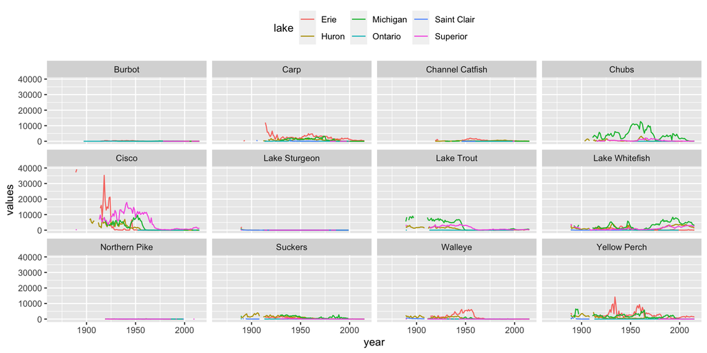

```r
fishing %>%
  filter(str_detect(region, "U.S. Total")) %>%
  filter(!is.na(region)) %>%
  mutate(species = fct_lump(species, 12)) %>%
  filter(species != "Other") %>%
  ggplot(aes(x = year, y = values, color = lake)) +
  geom_line() +
  facet_wrap(~species) +
  theme(legend.position = "top")
```

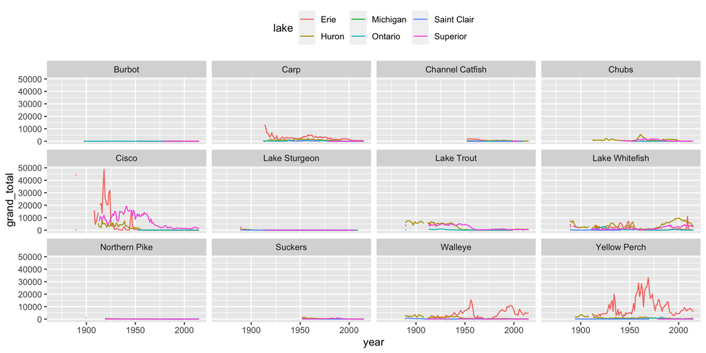

```r
fishing %>%
  filter(str_detect(region, "U.S. Total")) %>%
  filter(!is.na(region)) %>%
  mutate(species = fct_lump(species, 12)) %>%
  filter(species != "Other") %>%
  ggplot(aes(x = year, y = grand_total, color = lake)) +
  geom_line() +
  facet_wrap(~species) +
  theme(legend.position = "top")
```

### A model

I’m on a quest to learn `tidymodels`, so I’m going to try again today to model the given data. However, I am slightly uncomfortable with the idea of modeling this data because the idea of comparing things over time seems to violate all sorts of modeling conditions. Also, in the fishing dataset, one-third to one-half of the observations are missing. The data can’t possibly be missing at random! And last, I don’t understand the data. For example, the variable `agemonth` is described as the “Age in months.” The age of what? Presumably of the stocked fish, but a single row can’t be a single fish. So the stocked fish all come from the same clutch? Does that make sense? Also, what is `mark` (“marking method”) and `validation` (“validation method”) ? Seems like I should have much more knowledge about fishing and about these data before trying to model the data.

```r
stocked_small <- stocked %>%
  select(year, lake, stat_dist, no_stocked, agemonth, species, sid) %>%
  mutate(lake = factor(lake)) %>%
  #mutate(lake = ifelse(lake == "MI", "MI", "notMI")) %>%
  filter(!(species %in% c("LAH", "LAS", "SMB", "STN", "YEP"))) %>%
  drop_na()

set.seed(47)

data_split <- initial_split(stocked_small, prop = 2/3)

stocked_train <- training(data_split)
stocked_test <- testing(data_split)
```

#### recipe

Note to figure out: the `step_dummy()` line caused the random forest to not run. The outcome variable cannot have been formatted using `step_dummy()`. Also, if `step_dummy()` is applied to a variable, the role will be `predictor` even if the `update_role()` is used.

```r
stock_rec <-
  recipe(lake ~ ., data = stocked_train) %>%
  step_dummy(species) %>%
  update_role(stat_dist, sid, new_role = "ID")

summary(stock_rec)
```

```
## # A tibble: 7 x 4
##   variable   type    role      source
##   <chr>      <chr>   <chr>     <chr>
## 1 year       numeric predictor original
## 2 stat_dist  nominal ID        original
## 3 no_stocked numeric predictor original
## 4 agemonth   numeric predictor original
## 5 species    nominal predictor original
## 6 sid        numeric ID        original
## 7 lake       nominal outcome   original
```

Just to mix it up, we’re going to try to classify the data into the different lakes. There are five Great Lakes. First we specify that we’re going to use a Random Forest as the engine / model of interest:

```r
rf_mod1 <-
  rand_forest(mtry = 5,
              trees = 500,
              min_n = 5) %>%
  set_engine("ranger", importance = "permutation") %>%
  set_mode("classification")
```

After we’ve specified the engine, we can then `fit()` the model:

```r
stock_rf1 <-
  workflow() %>%
  add_model(rf_mod1) %>%
  add_recipe(stock_rec) %>%
  fit(data = stocked_train)

stock_rf1
```

```
## ══ Workflow [trained] ══════════════════════════════════════════════════════════
## Preprocessor: Recipe
## Model: rand_forest()
##
## ── Preprocessor ────────────────────────────────────────────────────────────────
## 1 Recipe Step
##
## • step_dummy()
##
## ── Model ───────────────────────────────────────────────────────────────────────
## Ranger result
##
## Call:
##  ranger::ranger(x = maybe_data_frame(x), y = y, mtry = min_cols(~5,      x), num.trees = ~500, min.node.size = min_rows(~5, x), importance = ~"permutation",      num.threads = 1, verbose = FALSE, seed = sample.int(10^5,          1), probability = TRUE)
##
## Type:                             Probability estimation
## Number of trees:                  500
## Sample size:                      16638
## Number of independent variables:  12
## Mtry:                             5
## Target node size:                 5
## Variable importance mode:         permutation
## Splitrule:                        gini
## OOB prediction error (Brier s.):  0.2538034
```

# vip

The variable importance plot gives a measure of which variable(s) was/were typically chosen first as the most important information to discriminate between the lakes.

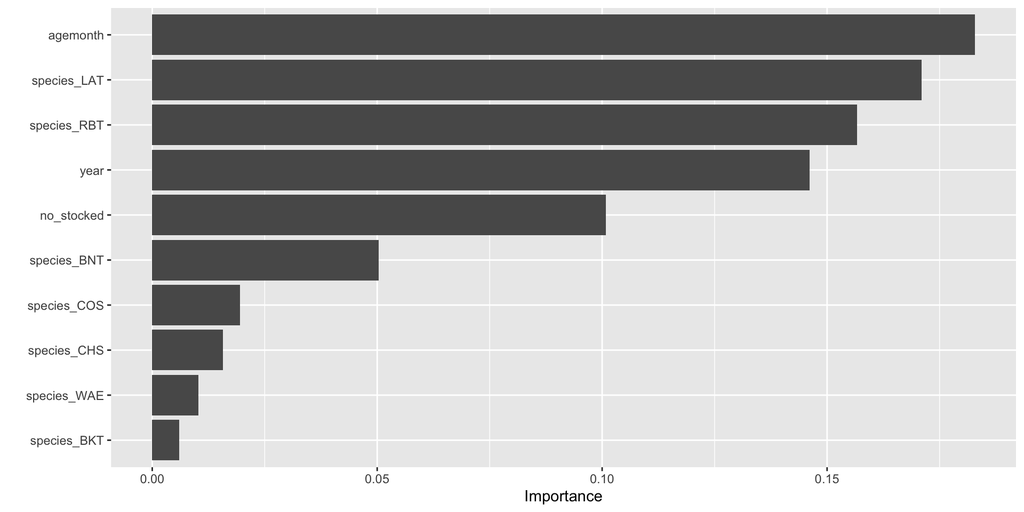

```r
library(vip)

stock_rf1 %>%
  pull_workflow_fit() %>%
  vip()
```

### CV to find a better values of `mtry` and `min_n` in the random forest.

```r
rf_mod2 <-
  rand_forest(mtry = tune(),
              trees = 500,
              min_n = tune()) %>%
  set_engine("ranger", importance = "permutation") %>%
  set_mode("classification")
```

After we’ve specified the engine, we can then `fit()` the model:

```r
stock_rf2 <-
  workflow() %>%
  add_model(rf_mod2) %>%
  add_recipe(stock_rec) %>%
  fit(data = stocked_train)

stock_rf2
```

```
## ══ Workflow [trained] ══════════════════════════════════════════════════════════
## Preprocessor: Recipe
## Model: rand_forest()
##
## ── Preprocessor ────────────────────────────────────────────────────────────────
## 1 Recipe Step
##
## • step_dummy()
##
## ── Model ───────────────────────────────────────────────────────────────────────
## Ranger result
##
## Call:
##  ranger::ranger(x = maybe_data_frame(x), y = y, mtry = min_cols(~tune(),      x), num.trees = ~500, min.node.size = min_rows(~tune(), x),      importance = ~"permutation", num.threads = 1, verbose = FALSE,      seed = sample.int(10^5, 1), probability = TRUE)
##
## Type:                             Probability estimation
## Number of trees:                  500
## Sample size:                      16638
## Number of independent variables:  12
## Mtry:                             12
## Target node size:                 16638
## Variable importance mode:         permutation
## Splitrule:                        gini
## OOB prediction error (Brier s.):  0.623763
```

Now we’ll CV the data so that we can run the random forest on different subsets of the training data.

```r
set.seed(4747)
stock_folds <- vfold_cv(stocked_train, v = 3)

stock_grid <- grid_regular(mtry(range = c(2, 13)),
                          min_n(range = c(5, 40)),
                          levels = 5)

stock_grid
```

```
## # A tibble: 25 x 2
##     mtry min_n
##    <int> <int>
##  1     2     5
##  2     4     5
##  3     7     5
##  4    10     5
##  5    13     5
##  6     2    13
##  7     4    13
##  8     7    13
##  9    10    13
## 10    13    13
## # … with 15 more rows
```

Now we tune the model, this time using the grid of parameter values. Note that our problem is classifying the lakes which is not binary. Therefore the default ROC metric will fail. We use `metric_set(accuracy)` as the measure of fit.

```r
doParallel::registerDoParallel()

set.seed(470)
tune_result <- tune_grid(
  stock_rf2,
  resamples = stock_folds,
  grid = stock_grid,
  metrics = metric_set(accuracy)
)

tune_result
```

```
## # Tuning results
## # 3-fold cross-validation
## # A tibble: 3 x 4
##   splits               id    .metrics          .notes
##   <list>               <chr> <list>            <list>
## 1 <split [11092/5546]> Fold1 <tibble [25 × 6]> <tibble [25 × 1]>
## 2 <split [11092/5546]> Fold2 <tibble [25 × 6]> <tibble [25 × 1]>
## 3 <split [11092/5546]> Fold3 <tibble [25 × 6]> <tibble [25 × 1]>
```

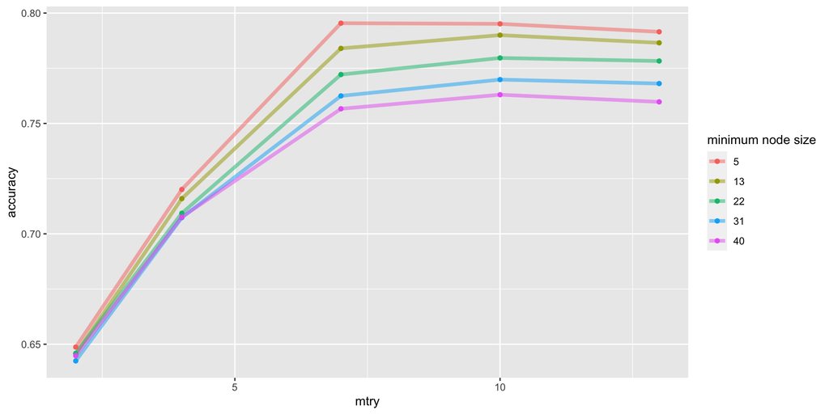

```r
tune_result %>%
  collect_metrics() %>%
  filter(.metric == "accuracy") %>%
  mutate(min_n = factor(min_n)) %>%
  ggplot(aes(x = mtry, y = mean, color = min_n)) +
  geom_line(alpha = 0.5, size = 1.5) +
  geom_point() +
  labs(y = "accuracy",
       color = "minimum node size")
```

### Fit to the test data

```r
rf_best <-
  rand_forest(mtry = 8,
              trees = 500,
              min_n = 5) %>%
  set_engine("ranger", importance = "permutation") %>%
  set_mode("classification")

stock_best <-
  workflow() %>%
  add_model(rf_best) %>%
  add_recipe(stock_rec) %>%
  fit(data = stocked_train)

stock_rf_final <-
  stock_best %>%
  last_fit(data_split, metrics = metric_set(accuracy))

stock_rf_final %>%
  collect_metrics()
```

```
## # A tibble: 1 x 4
##   .metric  .estimator .estimate .config
##   <chr>    <chr>          <dbl> <chr>
## 1 accuracy multiclass     0.809 Preprocessor1_Model1
```

```r
stock_rf_final %>%
  collect_predictions()
```

```
## # A tibble: 8,319 x 5
##    id               .pred_class  .row lake  .config
##    <chr>            <fct>       <int> <fct> <chr>
##  1 train/test split SU              2 SU    Preprocessor1_Model1
##  2 train/test split SU              3 SU    Preprocessor1_Model1
##  3 train/test split SU              5 SU    Preprocessor1_Model1
##  4 train/test split SU              6 SU    Preprocessor1_Model1
##  5 train/test split SU              8 SU    Preprocessor1_Model1
##  6 train/test split SU              9 MI    Preprocessor1_Model1
##  7 train/test split SU             10 MI    Preprocessor1_Model1
##  8 train/test split SU             11 SU    Preprocessor1_Model1
##  9 train/test split SU             13 SU    Preprocessor1_Model1
## 10 train/test split SU             24 MI    Preprocessor1_Model1
## # … with 8,309 more rows
```

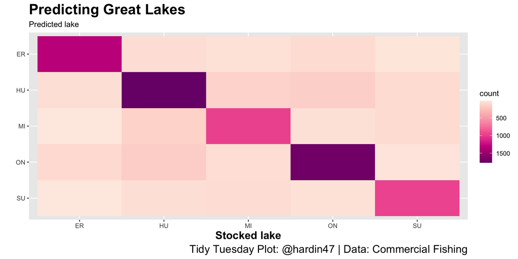

```r
stock_rf_final %>%
  collect_predictions() %>%
  select(.pred_class, lake) %>%
  group_by(.pred_class, lake) %>%
  summarize(count = n()) %>%
  ungroup() %>%
  ggplot() +
  geom_tile(aes(x = lake, y = reorder(.pred_class, desc(.pred_class)), fill = count)) +
    theme(
        axis.title=element_text(size=15,face="bold"),
        plot.title = element_text(size = 20, face = "bold"),
        plot.caption = element_text(size = 15)) +
  ylab("LDA topic")+
  scale_fill_distiller(palette = "RdPu", trans = "reverse") +
  labs(
    x = "Stocked lake", y = "",
    title = "Predicting Great Lakes",
    caption = "Tidy Tuesday Plot: @hardin47 | Data: Commercial Fishing",
    subtitle = "Predicted lake")
```